# A visual story of vehicles in public areas

## What vehicles appeared most often?

This visual data story is based on 50 vehicle observations collected through a Google Form. Each observation recorded the vehicle type, brand origin, cleanliness score, whether the vehicle appeared relatively new, and for the newest observations, where the vehicle was observed.

The first visualisation gives an overview of the vehicle types in the data. SUVs were the most common vehicle type in the observations, followed by sedans and hatchbacks. This gives the story a starting point by showing what kinds of vehicles appeared most often in the public areas I observed.

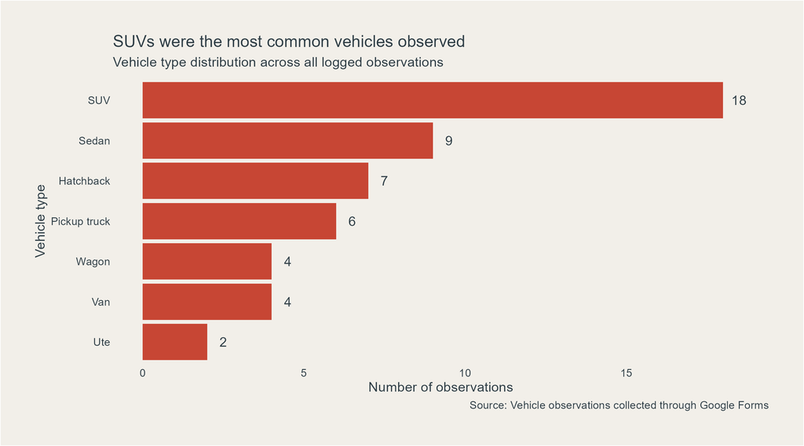

A horizontal bar chart showing the number of observations for each vehicle type, with SUVs as the most common vehicle type.

## How clean did vehicles appear by brand origin?

The second visualisation compares the mean cleanliness score for each brand origin. A score of 1 means very dirty and a score of 5 means very clean. This plot uses summarised data, so each bar represents the average cleanliness score for one brand origin group rather than a single vehicle.

In this data, Chinese and European vehicles had higher average cleanliness scores, while Japanese vehicles had a lower mean score. However, the number of observations in each brand origin group is not the same, so this pattern should be read as a feature of this logged sample rather than a general conclusion about all vehicles.

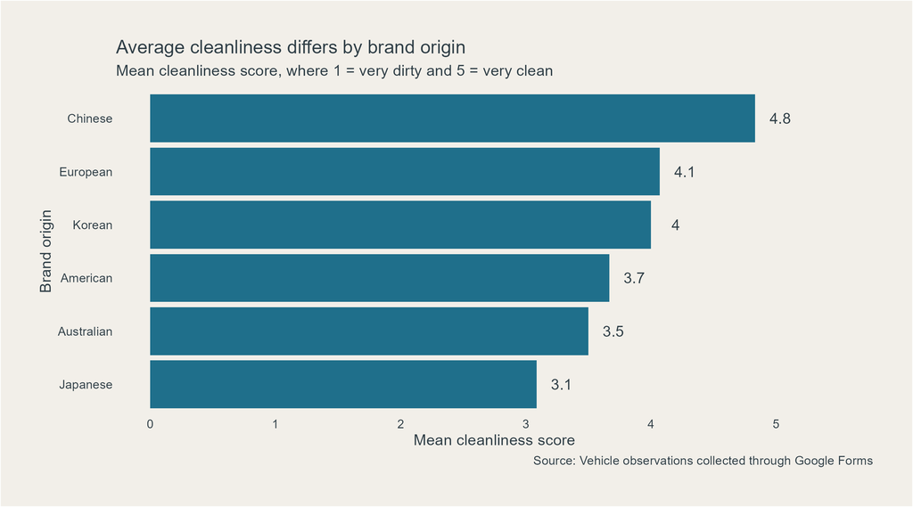

A horizontal bar chart comparing mean cleanliness score by brand origin, with scores shown from 0 to 5.

## Does location add another layer to the story?

For the newer observations, I added a question asking where the vehicle was observed. This gave more context to the data and helped make the story more interesting than just counting vehicle types.

The third visualisation groups vehicles into larger vehicles and smaller vehicles, then compares these groups across observation locations. Residential streets had the most observations with location recorded, and they included both larger and smaller vehicles. Shopping areas and car parks in this sample were only recorded with larger vehicles, while main roads had more smaller vehicles.

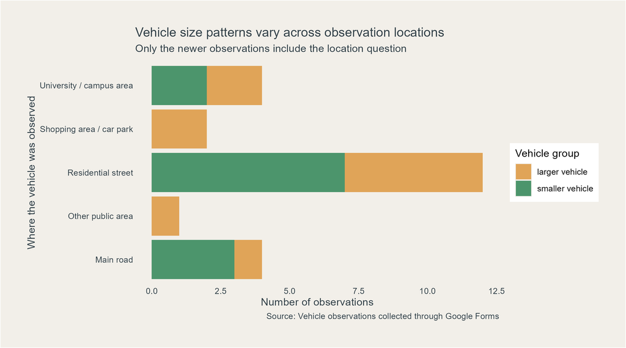

A stacked horizontal bar chart showing larger and smaller vehicle counts across observation locations.

## When was the data collected?

The timestamp from the Google Form was also useful for the story. I converted the timestamp into a date and counted how many observations were collected on each day.

The fourth visualisation shows that the observations were not collected evenly across all dates. Most observations were logged on a few collection days. This matters because the patterns in the previous plots are connected to when and where I was able to observe vehicles.

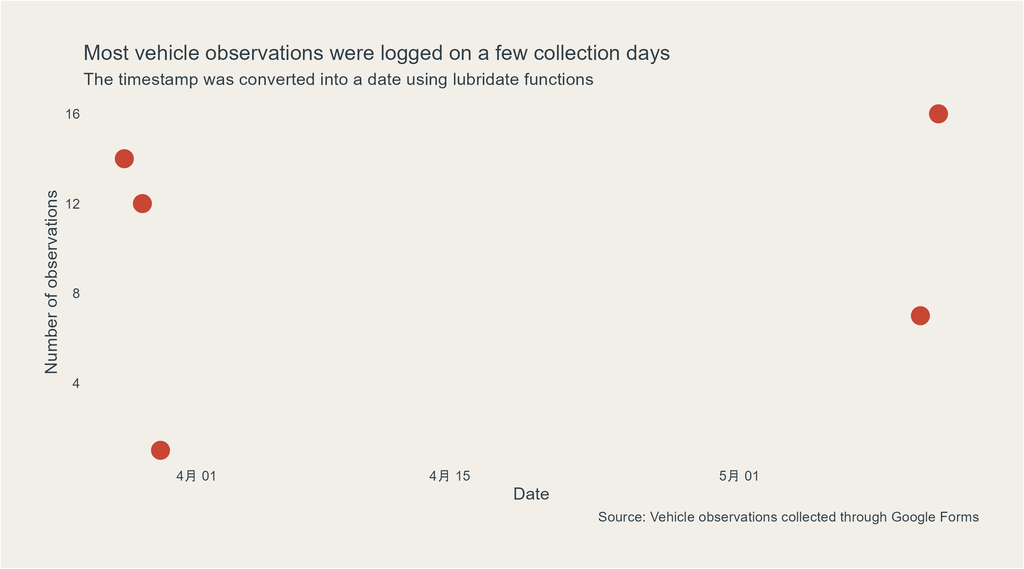

A point plot showing the number of vehicle observations collected on each date.

## What does the visual story suggest?

Together, the visualisations show that the observed vehicle patterns were shaped by both the type of vehicle and the context of observation. SUVs were common overall, cleanliness scores differed across brand origin groups, and the newer location variable helped show that the setting of an observation can change what kinds of vehicles are seen.

The main message of this visual story is that even a simple observational logging form can become more useful when the data includes both vehicle features and background context. Adding the location question made the data easier to read as a story because it connected the vehicles to the public places where they were observed.